# W12：雙樣本檢定——獨立與相依的差異

心理教育統計 2026

授課教師：陳紹慶 | e-mail: csc2009@mail.tcu.edu.tw

2026/05/18

# 本週學習目標

## 對應教材

- 《用 jamovi 上手統計學》
  - [第 11 章：比較兩個平均數](https://scgeeker.github.io/lsj-book-zh_tw/11-Comparing-two-means.html)

**簡報示範資料**：

- Harpo（獨立樣本 t）：兩位老師的教學成效
- Chico（相依樣本 t）：前後測的學生進步

**操作示範資料**：

- Zhang et al.(2024) Study 2資料全本(從google classroom下載”study2.csv”)

**作業資料**：個人化 `W12_ttest_Data_[學號].csv`

**理解概念**：

1. 區分**獨立樣本**與**相依樣本**的實驗設計
2. 理解 **Levene’s test** 的診斷功能
3. 知道何時使用 **Welch’s t** 修正
4. 掌握**相依樣本 t = 差值的單一樣本 t**

# Part 1：判斷你的實驗設計🧠

## 獨立 vs 相依

**獨立樣本（受試者間）**

- 兩組**不同的人**
- 例：A班 vs B班
- 蘋果 vs 橘子
- 例：實驗組 vs 控制組

**相依樣本（受試者內）**

- **同一批人**測兩次
- 例：前測 vs 後測
- 昨天的你 vs 今天的你
- 例：左眼 vs 右眼

## 判斷方法~資料來源

**提問**：每一筆資料之間，有沒有「配對關係」？

| 情境 | 類型 | 理由 |
| --- | --- | --- |
| A班 vs B班的成績 | 獨立 | 不同人 |
| 同一群人的前後測 | 相依 | 同一人測兩次 |
| 夫妻對的態度比較 | 相依 | 自然配對 |
| A 藥 vs B 藥（不同患者） | 獨立 | 不同人 |
| A 藥 vs B 藥（患者交叉服用） | 相依 | 同一人兩種藥 |

> 有配對 → 相依，沒配對 → 獨立

## 判斷方法~資料格式

**獨立樣本（受試者間）**

| ID | IV | DV |
| --- | --- | --- |
| 1 | A | 3 |
| 2 | A | 2 |
| 3 | A | 5 |
| 4 | B | 2 |
| 5 | B | 4 |
| 6 | B | 1 |

**相依樣本（受試者內）**

| ID | $DV_a$ | $DV_b$ |
| --- | --- | --- |
| 1 | 1 | 3 |
| 2 | 4 | 2 |
| 3 | 3 | 5 |
| 4 | 4 | 2 |
| 5 | 2 | 4 |

## 預覽jpower

- Modules -> Available -> 輸入”jpower” -> INSTALL
- 單一樣本t檢定操作示範

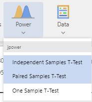

# Part 2：獨立樣本 t 檢定🧠👨‍💻

## Harpo 資料集

**情境**：比較兩位老師的教學成效

| 老師 | N | Mean | SD |
| --- | --- | --- | --- |
| Anastasia | 15 | 74.53 | 9 |
| Bernadette | 18 | 69.06 | 5.77 |

**問題**：Anastasia 的班平均高了約 5.5 分，這是真正的差異還是運氣？

## 兩組的分佈

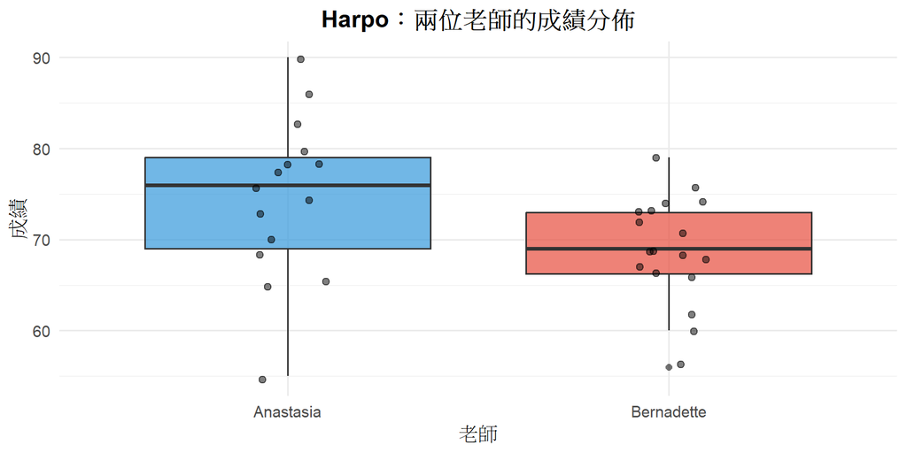

## 獨立樣本 t 的公式

$$t = \frac{\bar{X}_1 -
\bar{X}_2}{SE_{\text{pooled}}}$$

分母的聯合標準誤：

$$SE_{\text{pooled}} = s_p
\sqrt{\frac{1}{n_1} + \frac{1}{n_2}}$$

$$s_p = \sqrt{\frac{(n_1-1)s_1^2 +
(n_2-1)s_2^2}{n_1 + n_2 - 2}}$$

**自由度**：$df = n_1 + n_2 - 2 = 31$

## Harpo 的 t 檢定結果

$$t(31) = 2.12,\quad p = 0.043, CI_{95} =
[0.2, 10.8],\quad d = 0.74$$

- $p = 0.043 < .05$ → **拒絕 H₀**：兩組有顯著差異

## 效果量計算方法

**獨立樣本 t 的 Cohen’s d**：

$$d = \frac{\bar{X}_1 -
\bar{X}_2}{s_p}$$

- 分母 $s_p$：**聯合標準差**（合併兩組的 SD）
- 解讀：兩組平均差距佔 $s_p$ 的倍數
- Harpo 資料：$d = 0.74$（中效果）

> Cohen 效果量基準：小 ≥ 0.2、中 ≥ 0.5、**大 ≥ 0.8**

# Part 3：檢定變異數同質性🧠👨‍💻

## 適用條件：變異數同質性

Student’s t 假設兩組的取樣分佈**變異數相等**：

$$\hat{\sigma_1^2} =
\hat{\sigma_2^2}$$

如果不相等呢？

- 聯合標準誤 $s_p$ 的估計會有偏差

**Levene’s Test**：檢驗兩組變異數是否相等

- $p \geq .05$ → 同質 → 使用 Student’s t ✓
- $p < .05$ → 不同質 → 改用 **Welch’s t** ⚠
- 功能如同之前學過的Shapiro-Wilk Test

## 什麼是 Welch’s t？

**Student’s t** 假設兩組 SD 一樣 → 合併計算

**Welch’s t** 不做這個假設 → 分開計算

$$t = \frac{\bar{X}_1 -
\bar{X}_2}{\sqrt{\frac{s_1^2}{n_1} + \frac{s_2^2}{n_2}}}$$

**Student’s t vs. Welch’s t**：

- 自由度不是整數（使用Welch-Satterthwaite 法逼近）
- 更保守但更正確
- 許多統計學家建議，獨立組分析**一律使用 Welch’s t**

## 使用流程

```
執行 Independent Samples T-Test
         │
    勾選 Levene's Test
         │
    ┌────┴────┐
    │         │
 p ≥ .05   p < .05
    │         │
Student's t  Welch's t
 (同質)      (不同質)
    │         │
    └────┬────┘
         │
   報告 t, df, p, d
```

> 養成習慣：**先看 Levene’s檢定，再判讀 t 檢定結果**

## Harpo 的 Levene’s Test

Harpo 資料中：

- Anastasia 的 SD = 9
- Bernadette 的 SD = 5.77

Levene’s test: $p = 0.155$

- p ≥ .05 → **同質**，使用 Student’s t

## Independent Samples T-Test for Zhang 2024 study 2

**步驟**：

1. **T-Tests → Independent Samples T-Test**
2. 以Filter排除”Static Slides”
3. 將成績變項拖入 **Dependent Variables**
4. 將分組變項拖入 **Grouping Variable**
5. 勾選 **Effect Size**
6. 勾選 **Assumptions → Homogeneity test, Normality test**

# Part 4：相依樣本 t 檢定🧠👨‍💻

## Chico 資料集

**情境**：20 位學生接受補救教學，比較前後測成績

|  | Test 1 | Test 2 | 差值 (D) |
| --- | --- | --- | --- |
| Mean | 56.98 | 58.38 | 1.4 |
| SD | 6.62 | 6.41 | 0.97 |

## 相依 t 和單一樣本t

相依樣本 t 檢定 = **差值 (D)** 的單一樣本 t 檢定

$$D_i = X_{i,\text{後}} -
X_{i,\text{前}}$$

$$t = \frac{\bar{D} - 0}{SE_D} =
\frac{\bar{D}}{s_D / \sqrt{N}}$$

- $H_0$：$\mu_D = 0$（前後沒差）
- $H_1$：$\mu_D \neq 0$（前後有差）
- **$df = N - 1$**（不是 $N - 2$！只有一組數值）

## 差值分佈

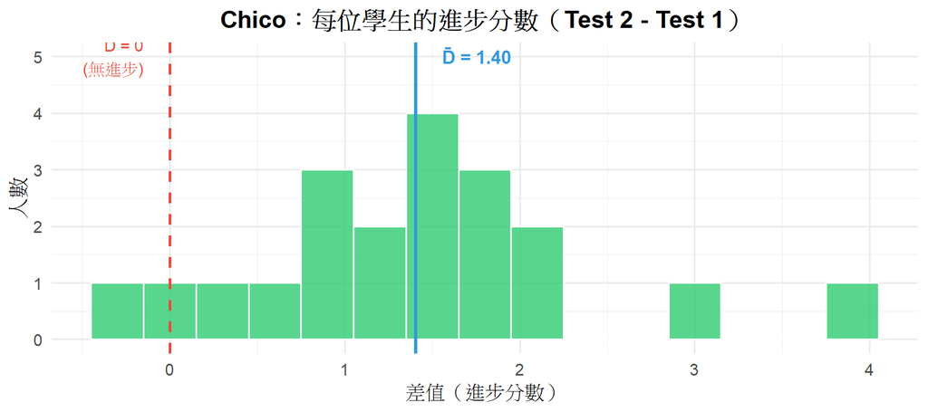

> 幾乎所有人都有進步（差值 > 0），但幅度不大

## Chico 的相依 t 結果

$$t(19) = 6.48,\quad p < .001,\quad d =
1.45$$

- $p < .001$ → **拒絕 $H_0$**：補救教學後成績顯著提升

## 效果量計算方法

**相依樣本 t 的 Cohen’s $d_z$**：

$$d_z = \frac{\bar{D}}{s_D}$$

- 分母 $s_D$：**差值的標準差**（不是個別組的 SD）
- 解讀：平均進步幅度佔差值 SD 的倍數
- Chico 資料：$d_z = 1.45$（大效果）

> ⚠ $d_z$ 與獨立樣本 $d$ 分母不同，**不可直接比較**

## 前後測的視覺化

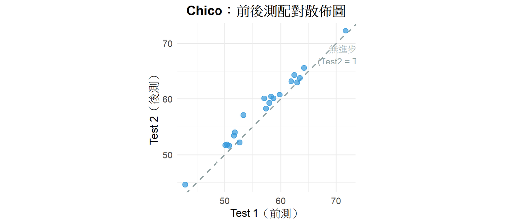

> 大部分點都在對角線**上方** → 後測 > 前測 → 有進步

## Paired Samples T-Test for Zhang 2024 study 2

**步驟**：

1. **T-Tests → Paired Samples T-Test**
2. 以Filter保留”Hands + Drawing”
3. 將前測和後測變項**依次拖入** Paired Variables
4. 勾選 **Effect Size**
5. 勾選 **Assumptions → Normality test**

**注意**：

- 如果資料中有分組，需先用 **Filter** 篩選目標組別
- 例如：只分析實驗組的前後測

# Part 5：樣本數,效果量,顯著水準,檢定力🧠👨‍💻

## 顯著 ≠ 重要

**p 值會隨 N 變化，效果量 d 不會**

|  | 小樣本（N = 50） | 大樣本（N = 500） |
| --- | --- | --- |
| 效果量 d | 0.5 | 0.5 |
| p 值 | .12（不顯著） | < .001（顯著） |

- 效果量衡量**差距的實質大小**，不受 N 影響
- **實質大小**: 以原始*測量尺度*計量(Y)或標準化(z,d)的數值
- APA 格式**必須同時報告 p 和 d**

## 統計檢定力（Power）

**Power = $1 − \beta$**：正確偵測到真實效果的機率

| 決定 ╲ 現實 | H₀ 為真 | H₁ 為真 |
| --- | --- | --- |
| **拒絕 $H_0$** | Type I Error ($\alpha$) | ✅ Power |
| **不拒絕 $H_0$** | ✅ 正確 | Type II Error ($\beta$) |

- **目標**：Power ≥ .80（慣例）
- Power 不足 → 真實效果可能被遺漏

## 四個互相牽連的參數

**確定其中 3 個，就能算出第 4 個**

| 參數 | 意義 | 慣例 |
| --- | --- | --- |
| **d**（效果量） | 預期效果大小 | 小 .2 ／ 中 .5 ／ 大 .8 |
| **$\alpha$** | 顯著水準 | .05 |
| **Power** | 偵測效果的機率 | ≥ .80 |
| **N** | 樣本數 | — |

## jpower：計算所需樣本數

**問題**：已知 d 和 $\alpha$，要達到 Power = .80，需要多少人？

1. 勾選 **Power** → 依實驗設計選擇t檢定類型 -> 展開 Power 分析面板
2. 選擇 **N per group** / **N**
3. 設定 Minimal Effect Size（例如：0.5）
4. 設定 $\alpha$ = .05，Power = .80
5. (選擇性) 檢定方向(雙側 vs. 單側); 各組樣本數比例
6. 報表輸出建議N表格

## 以 Harpo 資料規劃樣本數

Harpo 獨立樣本 t 的效果量：$d = 0.74$

**如果未來要重現這個效果（Power = .80），各組需要多少人？**

在 jpower 輸入：

- Effect Size d = 0.74
- $\alpha$ = .05，Power = .80
- **計算 N per group**
- 試試看：如果 Power 提高到 .95，N 會怎麼變化？

## 以 Chico 資料規劃樣本數

Chico 相依樣本 t 的效果量：$d_z = 1.45$

**如果未來要重現這個學習效果，需要多少人？**

在 jpower 選 **Paired Samples T-Test**，輸入：

- Effect Size d = 1.45
- $\alpha$ = .05，Power = .80
- **計算 N（配對數）**
- 相依設計通常比獨立設計需要**更少的人**
- 因為差值的 SD（$s_D$）比組間 SD 更小

# Part 6：作業說明

## 本週作業資料格式

**資料**：個人化 `W12_ttest_Data_[學號].csv`

你的資料包含：

| 變項 | 類型 | 說明 |
| --- | --- | --- |
| `ID` | ID | 受試者編號 |
| `Group` | Nominal | Experimental / Control |
| `Score_T1` | Continuous | 前測分數 |
| `Score_T2` | Continuous | 後測分數 |

**N = 50**（每組 25 人）

## 任務 1：獨立樣本 t（組間比較）

**操作**：比較「實驗組」與「控制組」在 **Score_T1** 是否有起點差異

1. 先執行 **Levene’s Test** → 記錄結果
2. 根據 Levene’s 結果選擇 Student’s t 或 Welch’s t
3. 勾選 Effect Size

**診斷報告**：

- 在報告中列出 Levene’s Test 結果
- 若不同質，說明為何改用 Welch’s t

## 任務 2：相依樣本 t（組內變化）

**操作**：針對「**實驗組**」，比較 Score_T1 與 Score_T2 是否有顯著進步

1. 使用 **Filter** 篩選出 Group == “Experimental”
2. 執行 **Paired Samples T-Test**
3. 勾選 Effect Size

## 任務 3：估計最小樣本數

1. 如果你要檢測比任務1算出的組間比較少一半的效果量，設定$\alpha$ = .05，power = .9，分組人數相同，使用單側檢定，各組至少需要多少人？
2. 如果你要檢測比任務2算出的組內變化多一倍的量，設定$\alpha$ = .01，power = .9，使用雙側檢定，至少需要多少人？

## 觀念辨析

1. **Q1**：請說明以下情境分別應使用獨立或相依樣本 t 檢定，並解釋原因：
1. 比較實驗組和控制組的考試成績
2. 比較同一群學生上課前和上課後的測驗分數
3. 比較數對夫妻對於家庭議題的態度量表評分
2. **Q2**：什麼是變異數同質性？為什麼確認比較分組平均數是違反變異數同質性，需要使用 Welch’s t檢定？
3. **Q3**：為什麼獨立 t 的 df = N-2，相依 t 的 df = N-1？

## 繳交要求

**檔案 1：學號_姓名_W12_Lab.omv**

- 含 Levene’s Test 結果
- 獨立樣本 t 檢定 + 相依樣本 t 檢定
- 勾選 Effect Size

**檔案 2：學號_姓名_W12_Report.docx**

- Levene’s 診斷報告
- 獨立 t 與相依 t 結果
- 2 段 APA 格式報告
- 3 題觀念辨析

**繳交期限**：本週上課結束前

# 小結與展望

## 下週預告

- 如果依變項是**類別**（而非數字），怎麼比較？
- 什麼是**觀測次數** vs **預期次數**？
- 什麼是**卡方檢定**（$\chi^2$）？

## 課後資源

**電子書**：

- [第 11 章：比較兩個平均數](https://scgeeker.github.io/lsj-book-zh_tw/11-Comparing-two-means.html)

**關鍵術語對照**：

| 中文 | 英文 | 符號 |
| --- | --- | --- |
| 獨立樣本 t | Independent Samples t-test | — |
| 相依樣本 t | Paired Samples t-test | — |
| 變異數同質性 | Homogeneity of Variance | — |
| Levene’s 檢定 | Levene’s Test | $F$ |
| Welch’s t | Welch’s t-test | $t_w$ |
| 聯合標準差 | Pooled SD | $s_p$ |